# quiz3_review

```python
from datascience import *
import numpy as np

%matplotlib inline
import matplotlib.pyplot as plots
plots.style.use('fivethirtyeight')
```

## If, Elif, Else

Write a function that generates a random number between 1 and 6 (inclusive). If the random number is 1, return the string 'One'. If the random number is 2, return the string 'Two'. For all other random numbers, return the string 'Neither one nor two'.

```python
def random_example1():
    bag = make_array(1,2,3,4,5,6)
    samples = np.random.choice(bag)
    if samples == 1:
        return 'One'
    elif samples == 2:
        return 'Two'
    else:
        return 'Neither one nor two'
```

```python
random_example1()
```

```
'Neither one nor two'
```

### Solution

```python
def random_example():
    six_arr = make_array(1,2,3,4,5,6)
    rand = np.random.choice(outcomes)

    if rand == 1:
        return 'One'
    elif rand == 2:
        return 'Two'
    else:
        return 'Neither one nor two'
```

## For loops and append

Suppose a bag contains 3 red balls and 7 green balls. Use a for loop and sample_proportions to perform the following experiment 1000 times:

- draw a ball from the bag 10 times
- calculate the number of red balls drawn
- append the number of red balls to an array

After the loop completes, visualize the outcomes using a histogram.

```python
ball_bag = make_array(3/10, 7/10)
outcomes = make_array()
for _ in np.arange(1000):
    sampled = sample_proportions(10, ball_bag)
    redballs = sampled.item(0)*10
    outcomes = np.append(outcomes, redballs)

redtable = Table().with_columns('Red Balls', outcomes)
redtable
```

| Red Balls |
| --- |
| 4 |
| 1 |
| 0 |
| 6 |
| 2 |
| 3 |
| 4 |
| 4 |
| 2 |
| 2 |

... (990 rows omitted)

## Solution

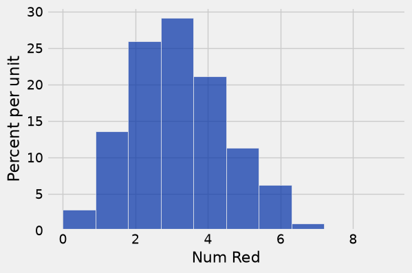

```python
bag_proportions = make_array(3/10, 7/10)
outcomes = make_array()

for _ in np.arange(1000):
    sample = sample_proportions(10, bag_proportions)
    num_red = sample.item(0) * 10
    outcomes = np.append(outcomes, num_red)

red_tbl = Table().with_column('Num Red', outcomes)
red_tbl.hist()
```

## Choosing the correct randomizer

Use np.random.choice, sample, or sample_proportions to generate the desired sample.

## Scenario 1

Select an element from the array arr with each element being equally likely.

```python
arr = make_array(1, 2, 3, 4)
np.random.choice(arr)
```

```
2
```

## Solution 1

```python
arr = make_array(1, 2, 3, 4)
np.random.choice(arr)
```

## Scenario 2

A bag contains 1 red ball, 3 green balls, and 6 yellow balls. Simulate the proportions resulting from drawing 5 balls from the bag (with replacement).

```python
bag_balls = make_array(1/10, 3/10, 6/10)
sample_proportions(5, bag_balls)
```

```
array([ 0. ,  0.2,  0.8])
```

## Solution 2

```python
bag_proportions = make_array(1/10, 3/10, 6/10)
sample = sample_proportions(5, bag_proportions)
sample
```

```
array([ 0. ,  0.6,  0.4])
```

## Scenario 3

Sample ten distinct movies from the table below.

```python
top_movies = Table.read_table('top_movies_2017.csv')
top_movies.sample(10, with_replacement=False)
```

| Title | Studio | Gross | Gross (Adjusted) | Year |
| --- | --- | --- | --- | --- |
| Rogue One: A Star Wars Story | Buena Vista | 532177324 | 537326000 | 2016 |
| Three Men and a Baby | Buena Vista | 167780960 | 370746600 | 1987 |
| Harry Potter and the Order of the Phoenix | Warner Brothers | 292004738 | 377314200 | 2007 |
| Frozen | Buena Vista | 400738009 | 435974700 | 2013 |
| Meet the Fockers | Universal | 279261160 | 392698200 | 2004 |
| Star Wars: Episode I - The Phantom Menace | Fox | 474544677 | 802874300 | 1999 |
| Toy Story 3 | Buena Vista | 415004880 | 464074600 | 2010 |
| American Sniper | Warner Brothers | 350126372 | 382981200 | 2014 |
| Indiana Jones and the Kingdom of the Crystal Skull | Paramount | 317101119 | 392622400 | 2008 |
| Gremlins | Warner Brothers | 153083102 | 404336400 | 1984 |

## Solution 3

```python
top_movies = Table.read_table('top_movies_2017.csv')
sample_tbl = top_movies.sample(10, with_replacement = False)
```